# R package qshift: A functional programming approach to shifted probability distributions

## Introduction

Shifted distributions are used daily in many statistical fields.  
Given a random variable $X$ with distribution function $F(x)$, a shifted random variable $Y$ from $X$ is a random variable with a constant, $k$, added, defined as $Y = X+k$, with distribution function $F(x-k)$. $Y$ support changes according to shift value.

The aim of this paper is to describe an R package, `qshift` which generates shifted distribution functions for any distribution chosen. The package was realized using a functional programming approach and inspires its computational method to Andrea Spanò article “R package `qdist`: A functional programming approach to truncated probability distributions”, which provides an alternative method for computing from truncated probability distributions using a functional programming approach.

## Shifted probability functions in R

R does not provide a specific package for shifted distribution functions, but it provides package `stats` which contains a wide set of functions for standard distributions: probability, density, quantile and random number generation functions. All them share a stable naming convention both for the names of the functions and in the first argument of these functions. In particular:

- density functions: `d<dist>(x)` with `x` vector of quantiles;
- probability distribution functions: `p<dist>(q)` with `q` vector of quantiles;
- quantile functions: `q<dist>(p)` with `p` vector of probabilities;
- random number generation: `r<dist>(n)` with `n` number of observations.

where `<dist>` indicates the conventional name of distribution family.

Let us see an example.  
Considering the Normal distribution (`norm`), we have: `dnorm(x)`, `pnorm(q)`, `qnorm(p)` and `rnorm(n)`.

So, we use to write:

```r
dnorm(x = 6:10, mean = 8, sd = 1)
```

```
## [1] 0.05399097 0.24197072 0.39894228 0.24197072 0.05399097
```

to get density values at 6:10 from a Normal distribution with parameters `mean = 8` and `sd = 1`.

Going back to shifted distribution, we could easily write a shifted version for `dnorm()`, as:

```r
shift_dnorm <- function(x, mean = 0, sd = 1, shift = 0, ...){
            x_shifted <- x - shift
            density <- dnorm(x = x_shifted, mean = mean, sd = sd, ...)
            return(density)
}
```

So we replicate the previous example but shifting the Normal distribution of 1 unit:

```r
shift_dnorm(x = 6:10, mean = 8, sd = 1, shift = 1)
```

```
## [1] 0.004431848 0.053990967 0.241970725 0.398942280 0.241970725
```

At first view, this approach seems easy and cool but thinking about it, we realize that we would need to write a different function for each probability distribution we would like to work with. Functional programming approach could be a solution, as Andrea Spanò demonstrates in his article (see “R package `qdist`: A functional programming approach to truncated probability distributions” for more details).

`qshift` package includes four general functions which compute shifted distribution functions for any distribution chosen:

- `dshift()` for shifted density functions;
- `pshift()` for shifted probability distributions;
- `qshift()` for shifted quantile functions;
- `rshift()` for shifted random numbers generation functions.

`qshift` package is available at https://github.com/veronicagiro/qshift.

```r
devtools::install_github("veronicagiro/qshift")
```

The four functions share the same logic: they take as input a probability distribution name, as a character string, and return the equivalent shifted distribution as a function object.

```r
require(qshift)
dsnorm <- dshift("norm") # density function
psnorm <- pshift("norm") # probability function
qsnorm <- qshift("norm") # quantile function
rsnorm <- rshift("norm") # random generation function
```

Talking about the computational process, package `qshift` is based on two key concepts being part of the functional nature of the R programming language:

- the environment of a function can be used as a placeholder for other objects;
- function formals can be manipulated.

For example, let us consider `dshift()`. As we seen, it takes as input the distribution name (`norm`) and proceeds as follows:

- gets the corresponding function `dnorm()`;
- uses `dnorm()` to create a function, say `density()` that computes shifted density for normal distributions;
- modify the formals of `density()` so that it has the same formals as `dnorm()` plus `shift`, corresponding to the shift value;
- returns `density()`.

So, the function `dsnorm()` has the same formals of the function `dnorm()`, plus the parameter `shift` which indicates the shift value to be applied to distribution; by default it is set as 0.

```r
args(dsnorm)
```

```
## function (x, mean = 0, sd = 1, log = FALSE, shift = 0)
## NULL
```

```r
args(dnorm)
```

```
## function (x, mean = 0, sd = 1, log = FALSE)
## NULL
```

Other references are in chapters [Environments](http://www.quantide.com/website/ramarro-chapter-03/) and [Functions](http://www.quantide.com/website/ramarro-chapter-04/) of Andrea Spanò weeb Book [Ramarro](http://www.quantide.com/website/ramarro-r-for-developers/), available on Quantide web site.

## Examples

Let us consider the Normal distribution and the previously defined functions `dsnorm()`, `psnorm()`, `qsnorm()` and `rsnorm()`.

- Density function, `dsnorm()`.  
  This function has a double use:
  - generate probability values from a non-shifted normal distribution by leaving parameter `shift` set to its default (`shift = 0`)
  - generate probability values from any shifted normal distribution by setting `shift` value

  ```r
  x <- seq(4, 14, len = 100)
  not_shifted <- dsnorm(x = x, mean = 8, sd = 1.5)
  positive_shifted <- dsnorm(x = x, mean = 8, sd = 1.5, shift = 1)
  negative_shifted <- dsnorm(x = x, mean = 8, sd = 1.5, shift = -1)
  ```

  We can visualize these results by plotting them:

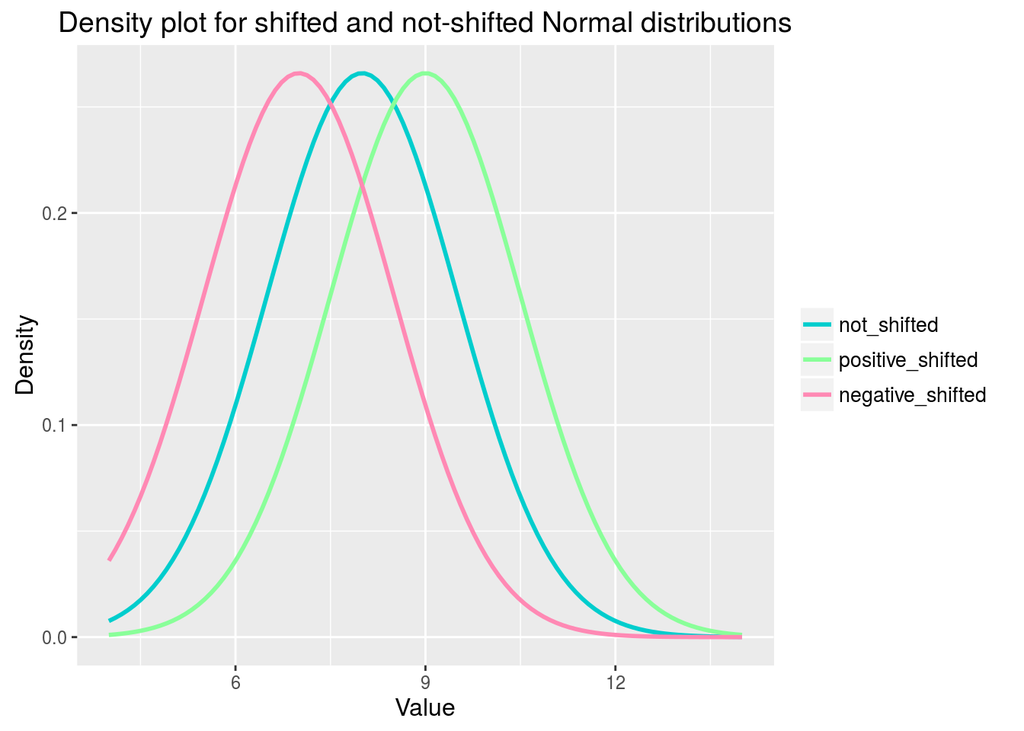

  ```r
  require(ggplot2)
  df <- data.frame(x=x,
               dsnorm_type = factor(c(rep("not_shifted", times=length(x)),
                  rep("positive_shifted", times=length(x)),
                  rep("negative_shifted", times=length(x))),
                  levels = c("not_shifted", "positive_shifted", "negative_shifted")),
                value = c(not_shifted, positive_shifted, negative_shifted))

  pl <- ggplot(data = df, mapping = aes(x=x, y=value, col=dsnorm_type)) +
    geom_line(size=1) +
    scale_color_manual(values = c("not_shifted" = "cyan3",
                              "positive_shifted" = "#89FF99",
                              "negative_shifted" = "#FF89B4")) +
    xlab("Value") + ylab("Density") +
    ggtitle("Density plot for shifted and not-shifted Normal distributions") +
    theme(legend.title=element_blank(), legend.text= element_text(size=10),
    plot.title = element_text(size=14), axis.title=element_text(size=12))

  print(pl)
  ```

- Probability function, `spnorm()`:

  ```r
  not_shifted <- psnorm(q = x, mean = 8, sd = 1.5)
  positive_shifted <- psnorm(q = x, mean = 8, sd = 1.5, shift = 1)
  negative_shifted <- psnorm(q = x, mean = 8, sd = 1.5, shift = -1)
  ```

  We can visualize these results by plotting them:

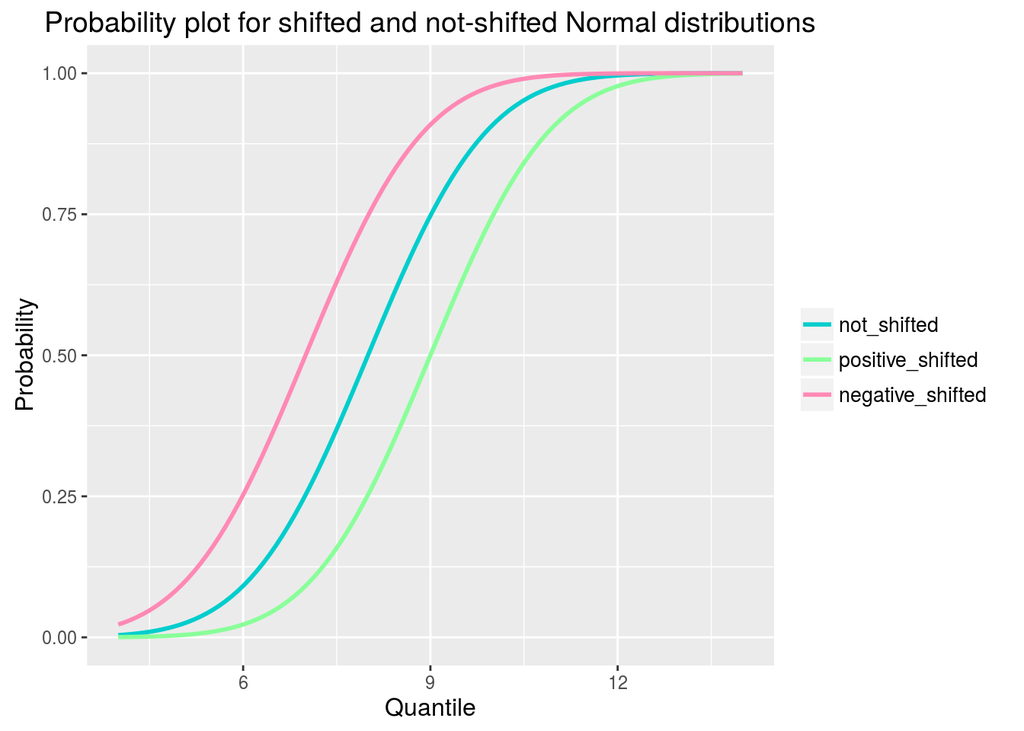

  ```r
  df <- data.frame(x=x,
               psnorm_type = factor(c(rep("not_shifted", times=length(x)),
                  rep("positive_shifted", times=length(x)),
                  rep("negative_shifted", times=length(x))),
                  levels = c("not_shifted", "positive_shifted", "negative_shifted")),
                value = c(not_shifted, positive_shifted, negative_shifted))

  pl <- ggplot(data = df, mapping = aes(x=x, y=value, col=psnorm_type)) +
    geom_line(size=1) +
    scale_color_manual(values = c("not_shifted" = "cyan3",
                              "positive_shifted" = "#89FF99",
                              "negative_shifted" = "#FF89B4")) +
    xlab("Quantile") + ylab("Probability") +
    ggtitle("Probability plot for shifted and not-shifted Normal distributions") +
    theme(legend.title=element_blank(), legend.text= element_text(size=10),
    plot.title = element_text(size=14), axis.title=element_text(size=12))

  print(pl)
  ```

- Quantile function, `qsnorm()`:

  ```r
  x <- (1:999)/1000
  not_shifted <- qsnorm(p = x, mean = 8, sd = 1.5)
  positive_shifted <- qsnorm(p = x, mean = 8, sd = 1.5, shift = 1)
  negative_shifted <- qsnorm(p = x, mean = 8, sd = 1.5, shift = -1)
  ```

  We can visualize these results by plotting them:

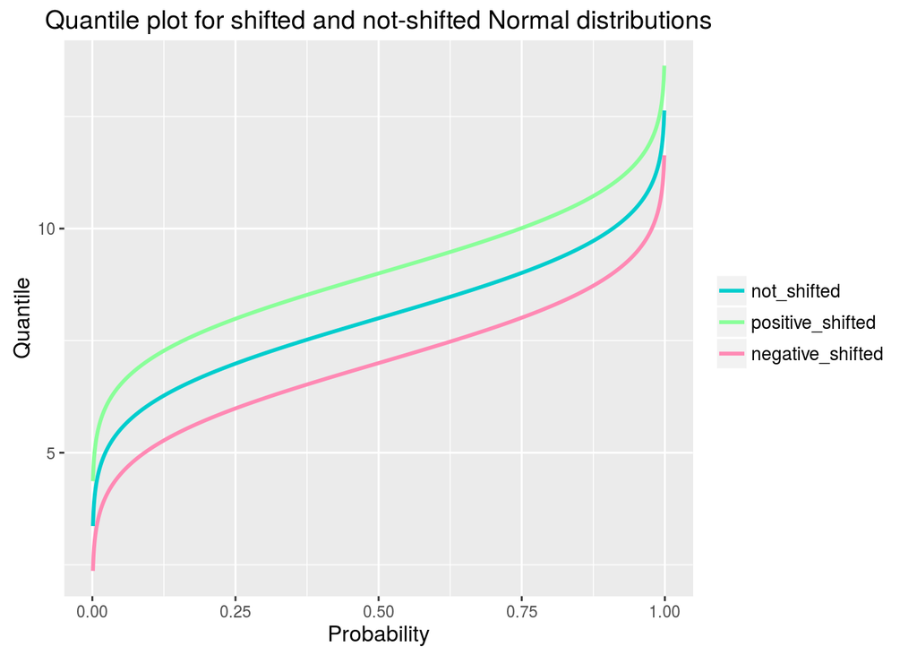

  ```r
  df <- data.frame(x=x,
               qsnorm_type = factor(c(rep("not_shifted", times=length(x)),
                  rep("positive_shifted", times=length(x)),
                  rep("negative_shifted", times=length(x))),
                  levels = c("not_shifted", "positive_shifted", "negative_shifted")),
                value = c(not_shifted, positive_shifted, negative_shifted))

  pl <- ggplot(data = df, mapping = aes(x=x, y=value, col=qsnorm_type)) +
    geom_line(size=1) +
    scale_color_manual(values = c("not_shifted" = "cyan3",
                              "positive_shifted" = "#89FF99",
                              "negative_shifted" = "#FF89B4")) +
    ylab("Quantile") + xlab("Probability") +
    ggtitle("Quantile plot for shifted and not-shifted Normal distributions") +
    theme(legend.title=element_blank(), legend.text= element_text(size=10),
    plot.title = element_text(size=14), axis.title=element_text(size=12))

  print(pl)
  ```

- Random generation function, `rsnorm()`:

  ```r
  x <- 100000
  not_shifted <- rsnorm(n = x, mean = 8, sd = 1.5)
  positive_shifted <- rsnorm(n = x, mean = 8, sd = 1.5, shift = 3)
  negative_shifted <- rsnorm(n = x, mean = 8, sd = 1.5, shift = -3)
  ```

  We can visualize these results by plotting them:

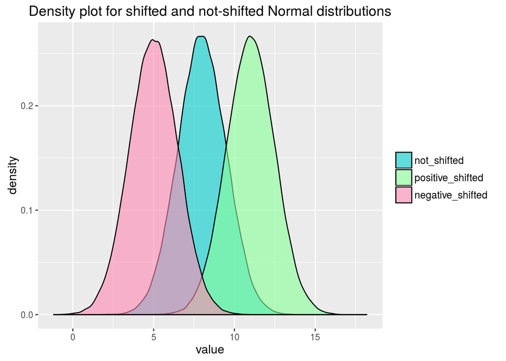

  ```r
  df <- data.frame(rsnorm_type = factor(c(rep("not_shifted", times=x),
                  rep("positive_shifted", times=x),
                  rep("negative_shifted", times=x)),
                  levels = c("not_shifted", "positive_shifted", "negative_shifted")),
                value = c(not_shifted, positive_shifted, negative_shifted))

  pl <- pl <- ggplot(data = df, mapping = aes(x=value, group=rsnorm_type, fill=rsnorm_type)) +
    geom_density(alpha=0.6) +
  scale_fill_manual(values = c("not_shifted" = "cyan3",
                              "positive_shifted" = "#89FF99",
                              "negative_shifted" = "#FF89B4")) +
    ggtitle("Density plot for shifted and not-shifted Normal distributions") +
    theme(legend.title=element_blank(), legend.text= element_text(size=10),
    plot.title = element_text(size=14), axis.title=element_text(size=12))

  print(pl)
  ```

As expected, the Normal shifted distribution is a Normal distribution with changed mean. The change in the mean is equal to the shift.

As we know, Normal distribution support goes from $-\infty$ to $+\infty$. What happens considerig a distribution with a limited support?  
Let us consider the Uniform distribution.

First of all we have to define its probability functions:

```r
dsunif <- dshift("unif")
psunif <- pshift("unif")
qsunif <- qshift("unif")
rsunif <- rshift("unif")
```

We limited Uniform support between 6 and 12.

- Density function, `dsunif()`:

  ```r
  x <- seq(4, 14, len = 100)
  not_shifted <- dsunif(x = x, min = 6, max = 12)
  positive_shifted <- dsunif(x = x, min = 6, max = 12, shift = 1)
  negative_shifted <- dsunif(x = x, min = 6, max = 12, shift = -1)
  ```

  We can visualize these results by plotting them:

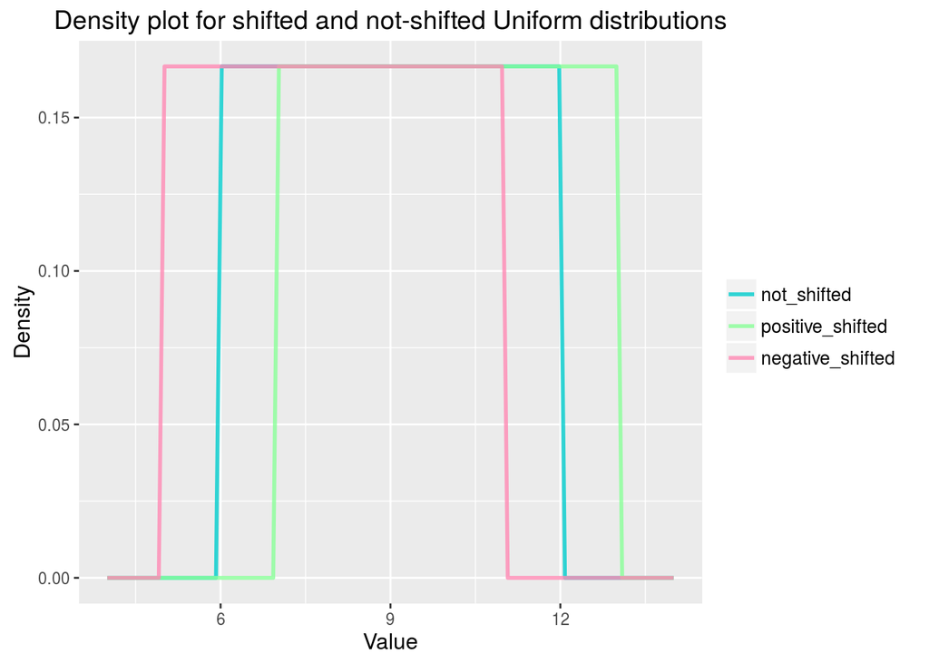

  ```r
  df <- data.frame(x=x,
               dsunif_type = factor(c(rep("not_shifted", times=length(x)),
                  rep("positive_shifted", times=length(x)),
                  rep("negative_shifted", times=length(x))),
                  levels = c("not_shifted", "positive_shifted", "negative_shifted")),
                value = c(not_shifted, positive_shifted, negative_shifted))

  pl <- ggplot(data = df, mapping = aes(x=x, y=value, col=dsunif_type)) +
    geom_line(size=1, alpha =0.8) +
    scale_color_manual(values = c("not_shifted" = "cyan3",
                              "positive_shifted" = "#89FF99",
                              "negative_shifted" = "#FF89B4")) +
    xlab("Value") + ylab("Density") +
    ggtitle("Density plot for shifted and not-shifted Uniform distributions") +
    theme(legend.title=element_blank(), legend.text= element_text(size=10),
    plot.title = element_text(size=14), axis.title=element_text(size=12))

  print(pl)
  ```

- Probability function, `psunif()`:

  ```r
  not_shifted <- psunif(q = x, min = 6, max = 12)
  positive_shifted <- psunif(q = x, min = 6, max = 12, shift = 1)
  negative_shifted <- psunif(q = x, min = 6, max = 12, shift = -1)
  ```

  We can visualize these results by plotting them:

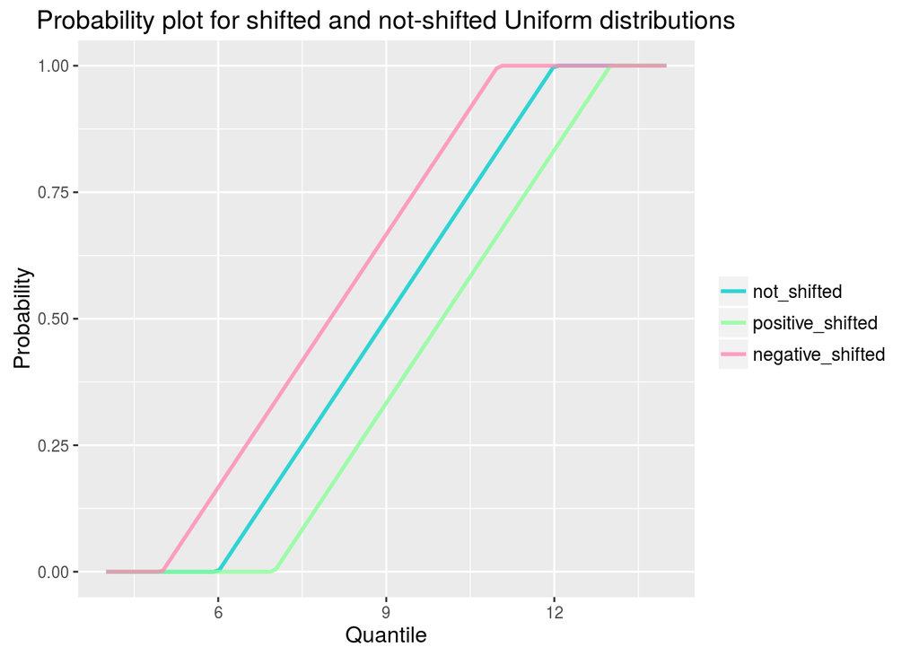

  ```r
  df <- data.frame(x=x,
               psunif_type = factor(c(rep("not_shifted", times=length(x)),
                  rep("positive_shifted", times=length(x)),
                  rep("negative_shifted", times=length(x))),
                  levels = c("not_shifted", "positive_shifted", "negative_shifted")),
                value = c(not_shifted, positive_shifted, negative_shifted))

  pl <- ggplot(data = df, mapping = aes(x=x, y=value, col=psunif_type)) +
    geom_line(size=1, alpha =0.8) +
    scale_color_manual(values = c("not_shifted" = "cyan3",
                              "positive_shifted" = "#89FF99",
                              "negative_shifted" = "#FF89B4")) +
    xlab("Quantile") + ylab("Probability") +
    ggtitle("Probability plot for shifted and not-shifted Uniform distributions") +
    theme(legend.title=element_blank(), legend.text= element_text(size=10),
    plot.title = element_text(size=14), axis.title=element_text(size=12))

  print(pl)
  ```

- Quantile function, `qsunif()`:

  ```r
  x <- (1:999)/1000
  not_shifted <- qsunif(p = x, min = 6, max = 12)
  positive_shifted <- qsunif(p = x, min = 6, max = 12, shift = 1)
  negative_shifted <- qsunif(p = x, min = 6, max = 12, shift = -1)
  ```

  We can visualize these results by plotting them:

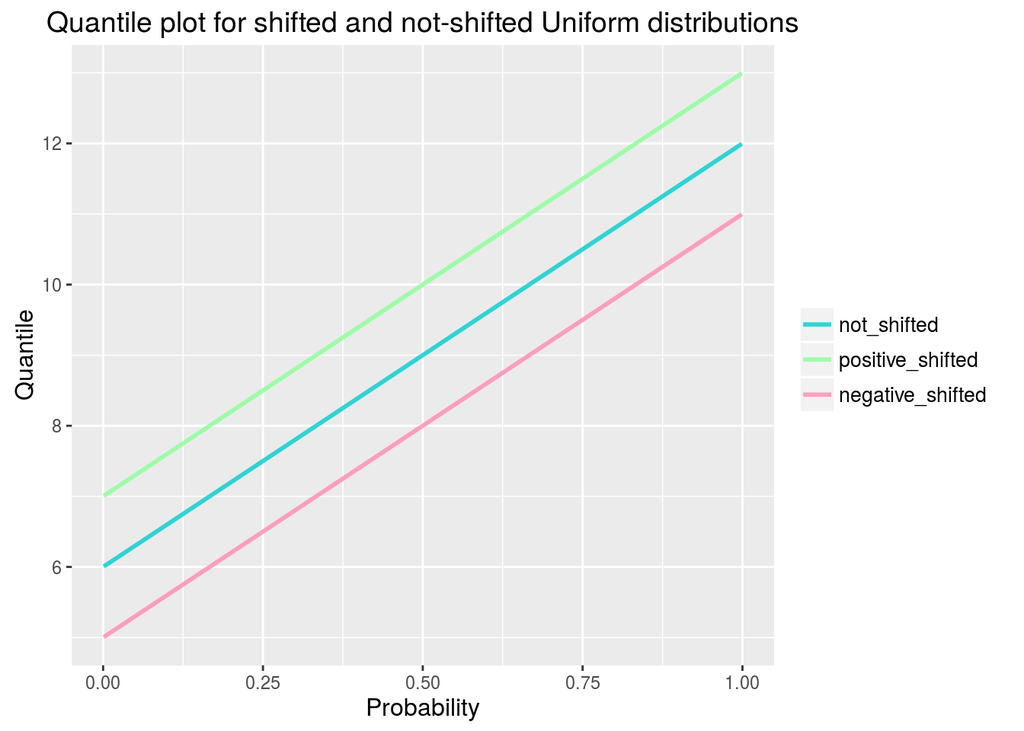

  ```r
  df <- data.frame(x=x,
               qsunif_type = factor(c(rep("not_shifted", times=length(x)),
                  rep("positive_shifted", times=length(x)),
                  rep("negative_shifted", times=length(x))),
                  levels = c("not_shifted", "positive_shifted", "negative_shifted")),
                value = c(not_shifted, positive_shifted, negative_shifted))

  pl <- ggplot(data = df, mapping = aes(x=x, y=value, col=qsunif_type)) +
    geom_line(size=1, alpha =0.8) +
    scale_color_manual(values = c("not_shifted" = "cyan3",
                              "positive_shifted" = "#89FF99",
                              "negative_shifted" = "#FF89B4")) +
    ylab("Quantile") + xlab("Probability") +
    ggtitle("Quantile plot for shifted and not-shifted Uniform distributions") +
    theme(legend.title=element_blank(), legend.text= element_text(size=10),
    plot.title = element_text(size=14), axis.title=element_text(size=12))

  print(pl)
  ```

- Random generation function, `rsunif()`:

  ```r
  x <- 1000
  not_shifted <- rsunif(n = x, min = 6, max = 12)
  positive_shifted <- rsunif(n = x, min = 6, max = 12, shift = 3)
  negative_shifted <- rsunif(n = x, min = 6, max = 12, shift = -3)
  ```

  We can visualize these results by plotting them:

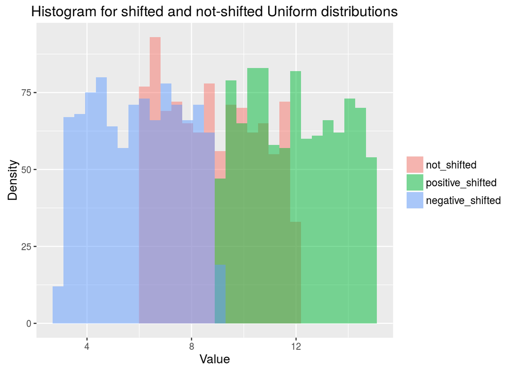

  ```r
  df <- data.frame(rsunif_type = factor(c(rep("not_shifted", times=x),
                  rep("positive_shifted", times=x),
                  rep("negative_shifted", times=x)),
                  levels = c("not_shifted", "positive_shifted", "negative_shifted")),
                value = c(not_shifted, positive_shifted, negative_shifted))


  pl <- ggplot(data = df, mapping = aes(x=value, fill=rsunif_type, group=rsunif_type)) +
    geom_histogram(alpha=0.5, bins = 30, position="identity") +
  scale_color_manual(values = c("not_shifted" = "cyan3",
                              "positive_shifted" = "#89FF99",
                              "negative_shifted" = "#FF89B4")) +
    xlab("Value") + ylab("Density") +
    ggtitle("Histogram for shifted and not-shifted Uniform distributions") +
    theme(legend.title=element_blank(), legend.text= element_text(size=10),
    plot.title = element_text(size=14), axis.title=element_text(size=12))

  print(pl)
  ```

As we see, Uniform support changes according to the transformation (the shift) applied to the distribution.

## Extending the computation

Further implementations are possible starting from the definition of a shifted distribution.  
Suppose we want to define a function for maximum likelihood estimate for the shifted Weibull distribution.

Firstly let us define the shifted density function for the Weibull distribution:

```r
dsweibull <- dshift("weibull")
```

and, subsequently, by using `dsweibull()` within an estimator function:

```r
lsweibull <- function(x){
  # starting values for parameters (scale, shape) and shift
  shift <- min(x) - 0.01
  x1 <- x - shift
  shape <- (sd(x1)/mean(x1))^(-1.086)
  scale <- mean(x1)/gamma(1+1/shape)
  # parameters vector definition
  theta <- c(shape, scale, shift)
  # likelihood function
  ll <- function(theta, x){
    shape <- theta[1]
    scale <- theta[2]
    shift <- theta[3]
    ld <- dsweibull(x = x, shape = shape, scale = scale, shift = shift, log = TRUE)
    -sum(ld)
  }
  # maximum likelihood estimation
  optim(par = theta, fn = ll, x = x)[["par"]]
}
```

Let us see how it works on a random generated sample from a shifted Weibull distribution:

```r
# generate a random sample from a shifted weibull distribution
rsweibull <- rshift("weibull")
x <- rsweibull(n = 100000, shape = 1, scale = 5, shift = 1)

# maximum likelihood estimate for the shifted weibull distribution
lsweibull(x = x)
```

```
## [1] 1.007325 5.025450 1.000020
```

## Bibliography

Pace L., Salvan A. . *Introduzione alla Statistica*. CEDAM. 2010

Spanò A. . *R package qdist: A functional programming approach to truncated probability ditributions*. url

Wickham H. . *Advanced r*. http://adv-r.had.co.nz/. Accessed: 2016-08-24.